# Coursera DataProducts Assignment

Decision Quality Shiny App

Joseph Kahn

Monday, June 23, 2014

## Goals

Before begining a data science task, it is most important to determine the purpose of the analysis. Often, we are performing analysis in support (directly or indirectly) of decision making. A broader picture of decision making considers the entire decision analysis cycle.

Based on the [Decision Education Foundation](http://www.decisioneducation.org), there are 6 elements to acheiving decision quality:

1. Appopriate Frame
2. Clear Objectives
3. Creative Alternatives
4. Useful Information
5. Sound Reasoning
6. Commitment to Action

This [Decision Quality Shiny App](http://josephmkahn.shinyapps.io/DecisionQuality) helps to facilitate good decision making by highlighting the key steps, and allowing users to visually display the weak points in overall decision quality.

## Decision Quality Scale

Each element of decision quality can be rated from 0% up to 100%. Although we could spend forever on any element, we mark 100% as the point at which it is no longer worth the extra effort to improve that element. The table below gives guidance at what 0% and 100% should look like for each element.

|  | At 0% | At 100% |
| --- | --- | --- |
| Appropriate Frame | Divergent understanding of purpose, but plowing ahead anyway | Alignment by key stakeholders and experts, and committed to the process |
| Clear Objectives | Missing key stakeholders, unclear on prime value drivers, ignoring important intangibles | Quantitative tradeoffs among stakeholders’ key metrics, including time and risk preferences |
| Creative Alternatives | One option / Business as Usual | Multiple compelling Strategies |
| Useful Information | Lacking info on key inputs, point estimates rather than ranges/distributions | Relevant info assessed and reviewed from trusted sources. Ranges and uncertainties well characterized |
| Sound Reasoning | Missing key issues, while over-complex on others. Results are confusing to the decision maker | Best choice(s) are clear, model is trusted, insights verified and robust |
| Commitment to Action | Lack of stakeholder support, organizational hurdles, continual rework, too early or too late | Stakeholders bought in, team aligned, resources committed |

## Example: lack of creative alternatives

This plot demonstrates where we have not considered any alternatives other than business as usual. As a result, stakeholders have not committed to the strategy.

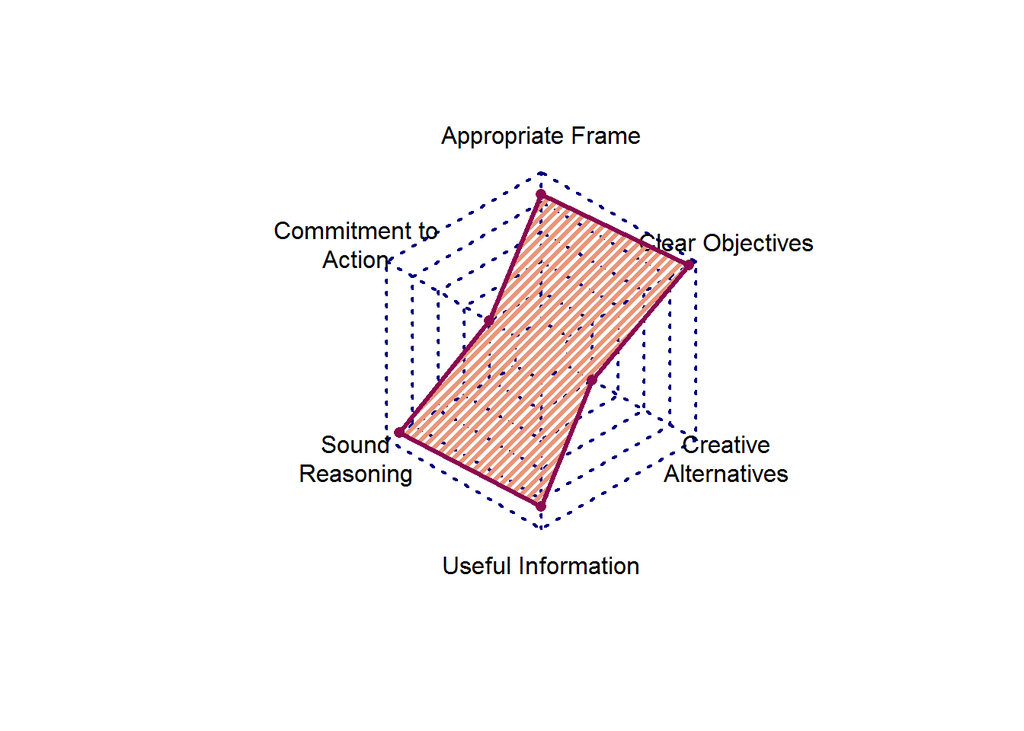

## Example: High decision quality

This plot demonstrates where all elements of decision quality have been adequately addressed, helping stakeholders to commit to action.

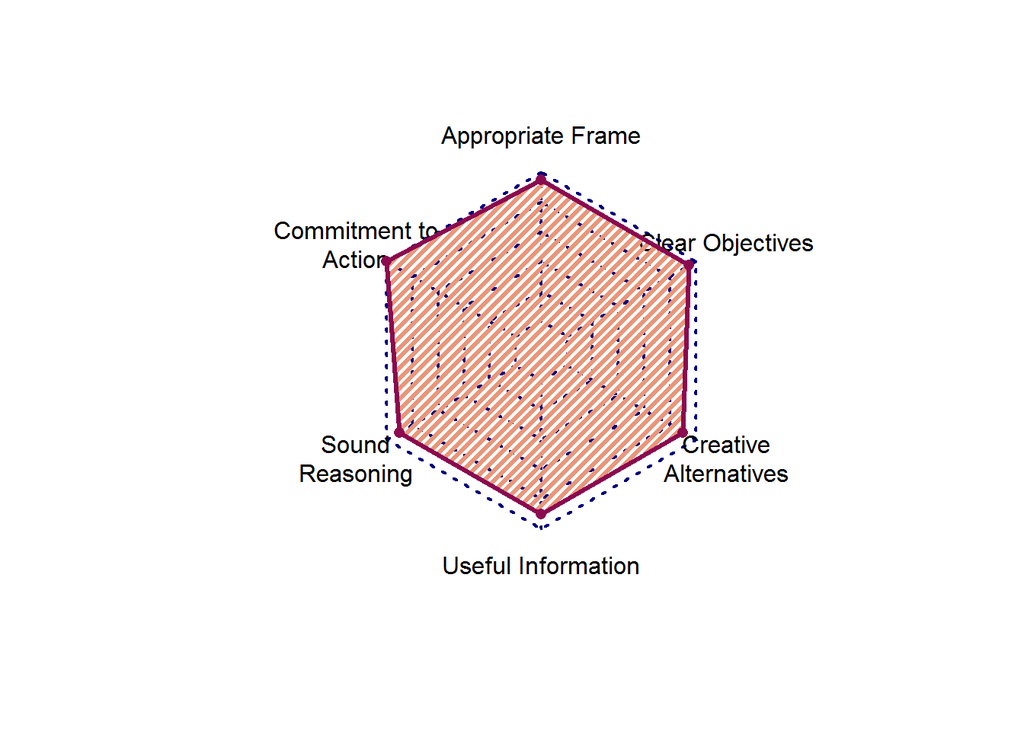

## Conculsions

This Decision Quality Shiny App assists users in thinking about the elements of decision quality The App is live at Shiny.io http://josephmkahn.shinyapps.io/DecisionQuality. Code and this presentation is archived on github https://github.com/josephmkahn/DataProductsAssignment in the ShinyApp folder.

Acknowledgements to:

- The Decision Education Foundation http://www.decisioneducation.org
- fmsb R package, for the “radar” plot
- Vineet Joshi, for assisting with cration of radar plots
- Coursera for hosting the class
- Rstudio for creating Shiny and hosting shiny.io
- Creators of knitr and slidify
- Our data products and data science instructors at Johns Hopkins!